# Clinical Visit Insights

David Willsher

> **Executive Summary**  
> This report demonstrates a scalable R-based automation pipeline for extracting, cleaning, validating, and summarising clinical visit data from a Snowflake warehouse. It highlights how structured patient data, including embedded JSON, can be transformed into usable insights. This workflow enhances operational efficiency, supports healthcare research, and ensures high-quality data governance.

# 1 1. Project Overview

The pipeline pulls data from a Snowflake-hosted table (`clinical_visits_2`), parses nested JSON `vitals`, applies QA checks, and produces department-level summaries and visual insights. All credentials are securely managed via the `keyring` package, and outputs are saved for downstream use or reporting.

# 2 2. Setup

The data was extracted using an ODBC connection and saved as CSVs for reproducibility.

# 3 3. Data Structure & Parsing

Each row in the dataset represents a clinical visit. The `vitals` field originally contained a JSON string with multiple readings. This was parsed into structured `bp` (blood pressure) and `temp` (temperature) columns.

## 3.1 Sample Rows

| patient_id | age | gender | visit_date | department | admitted | diagnosis_code | vitals | bp | temp |
| --- | --- | --- | --- | --- | --- | --- | --- | --- | --- |
| P0001 | 32 | Male | 2024-10-22 | Orthopaedics | FALSE | C34 | {"bp": "114/68", "temp": 37.8} | 114/68 | 37.8 |
| P0002 | 87 | Male | 2023-09-08 | Respiratory | FALSE | I10 | {"bp": "101/65", "temp": 36.5} | 101/65 | 36.5 |
| P0003 | 82 | Other | 2023-07-03 | Cardiology | TRUE | I20 | {"bp": "141/94", "temp": 37.0} | 141/94 | 37.0 |
| P0004 | 75 | Other | 2025-01-09 | Neurology | TRUE | E11 | {"bp": "151/70", "temp": 37.7} | 151/70 | 37.7 |
| P0005 | 61 | Female | 2024-01-13 | Oncology | TRUE | E11 | {"bp": "121/66", "temp": 36.2} | 121/66 | 36.2 |

# 4 4. QA Checks & Validation

The following checks were applied:

- Missing values in `age`, `gender`, `bp`, or `temp`
- Implausible values:
  - `age < 0` or `age > 120`
  - `temp < 35°C` or `temp > 42°C`

## 4.1 QA Issues by Reason

| reason | count |
| --- | --- |

# 5 5. Department-Level Summary

This summary shows patient distribution across departments and admission rates.

| department | admitted | total_patients | avg_age | avg_temp |
| --- | --- | --- | --- | --- |
| Respiratory | TRUE | 50 | 63.6 | 37.1 |
| Respiratory | FALSE | 46 | 53.1 | 37.1 |
| Neurology | FALSE | 45 | 50.0 | 37.3 |
| Orthopaedics | FALSE | 45 | 55.2 | 37.4 |
| Cardiology | TRUE | 44 | 59.2 | 37.3 |
| Neurology | TRUE | 43 | 54.2 | 37.2 |
| Geriatrics | TRUE | 41 | 56.5 | 37.2 |
| Oncology | TRUE | 41 | 53.6 | 37.4 |
| Geriatrics | FALSE | 39 | 52.3 | 37.2 |
| Orthopaedics | TRUE | 37 | 50.8 | 37.4 |

[output cut: 2 more lines]

# 6 6. Visual Insights

## 6.1 Patient Count by Department

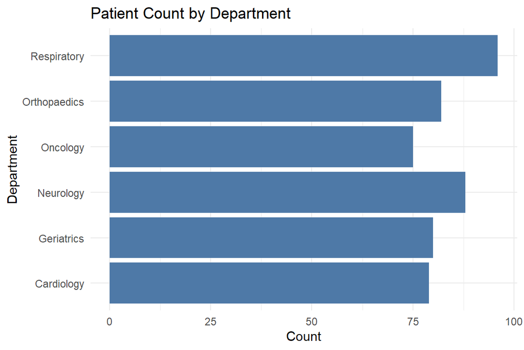

## 6.2 Temperature Distribution

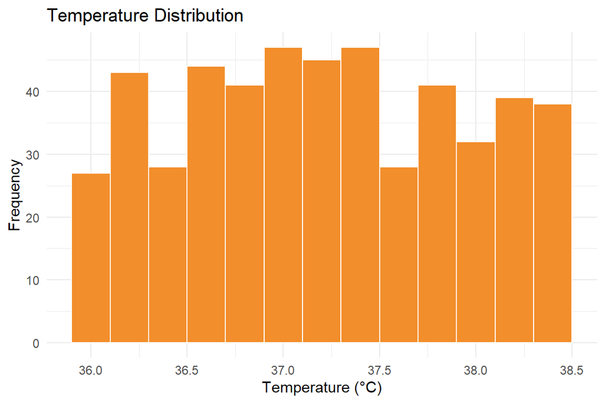

# 7 7. Observations and Business Relevance

## 7.1 Operational Efficiency

- Automatically processes raw clinical visit data with minimal manual effort
- Streamlined JSON parsing and QA allow for scalable report generation

## 7.2 Clinical & Research Value

- Enables rapid triage or analysis of abnormal patient presentations
- Clean vitals can feed into downstream models (e.g., risk scoring, alerts)

## 7.3 Data Governance

- Built-in checks flag bad data early, improving reliability of any decisions
- Uses secure credential storage (via `keyring`) for GDPR compliance and security

# 8 8. Reproducibility Notes

- This report was generated using a reproducible R pipeline stored in GitHub.
- Credentials are **not** stored in the script and must be provided via `keyring`.
- Outputs include:
  - `cleaned_clinical_visits.csv`
  - `qa_issues.csv`
  - `department_summary.csv`

> *Developed by David Willsher — showcasing scalable automation for clinical data insight generation.*